# R Practical Codes

### Gamma Distribution

Generalizes the exponential distribution and is often used in modeling waiting times.

```r
gamma_data <- dgamma(x, shape = 2, rate = 0.5)
plot_gamma <- data.frame(x, gamma_data)
```

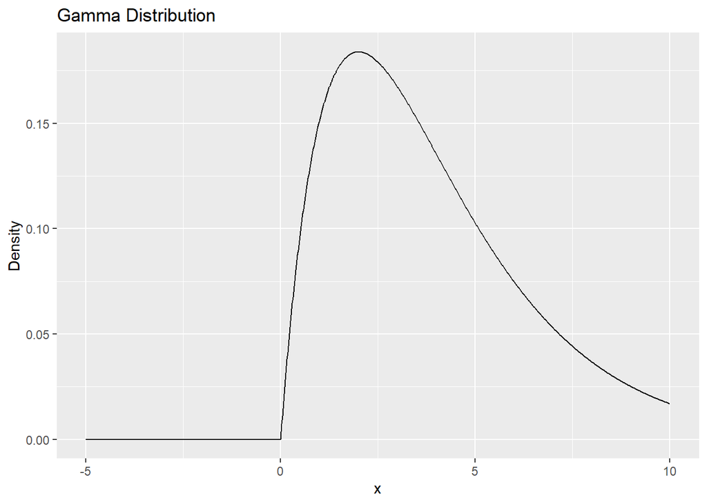

```r
ggplot(plot_gamma, aes(x, gamma_data)) +
  geom_line() +
  ggtitle("Gamma Distribution") +
  xlab("x") + ylab("Density")
```

### Chi-Squared Distribution

Arises in the context of the sum of squared standard normal random variables and is widely used in hypothesis testing.

```r
chi_squared_data <- dchisq(x, df = 5)
plot_chi_squared <- data.frame(x, chi_squared_data)
```

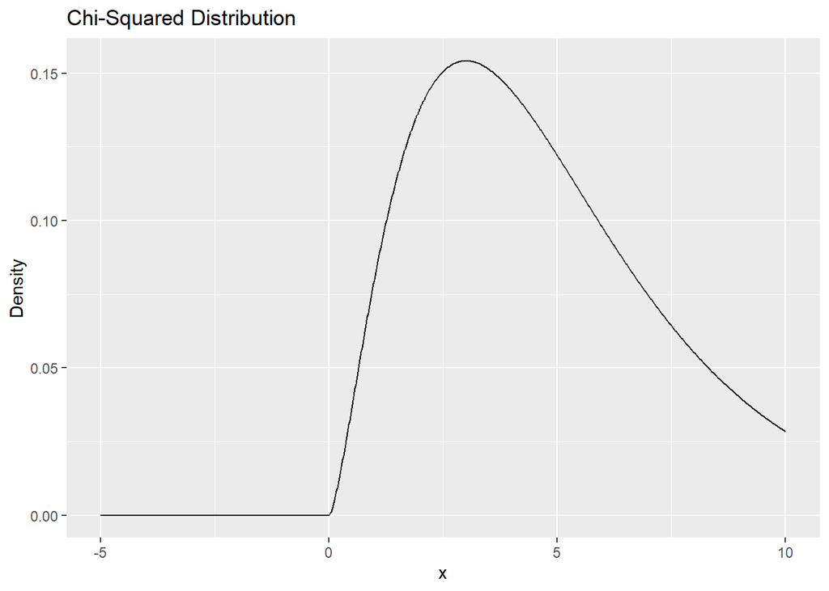

```r
ggplot(plot_chi_squared, aes(x, chi_squared_data)) +
  geom_line() +
  ggtitle("Chi-Squared Distribution") +
  xlab("x") + ylab("Density")
```

### Cauchy Distribution

Known for its heavy tails, often used to model outliers and extreme events.

```r
cauchy_data <- dcauchy(x, location = 2, scale = 1)
plot_cauchy <- data.frame(x, cauchy_data)
```

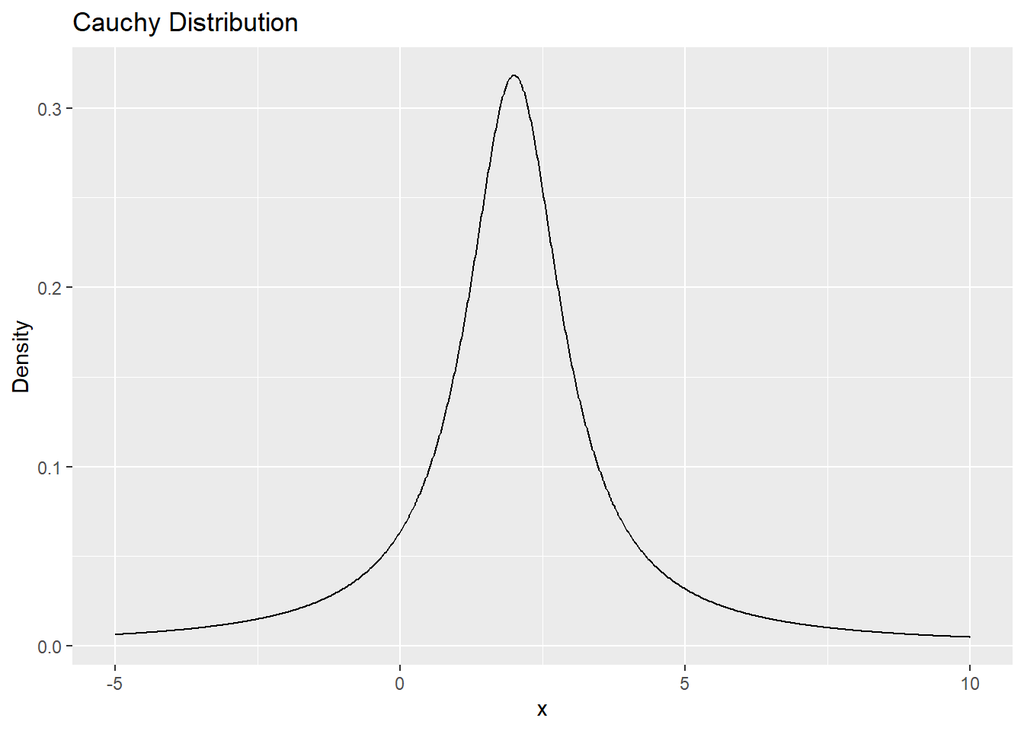

```r
ggplot(plot_cauchy, aes(x, cauchy_data)) +
  geom_line() +
  ggtitle("Cauchy Distribution") +
  xlab("x") + ylab("Density")
```

### Beta Distribution

Used to model random variables that are constrained to the interval [0, 1], often used for modeling proportions.

```r
beta_data <- dbeta(x, shape1 = 2, shape2 = 5)
plot_beta <- data.frame(x, beta_data)
```

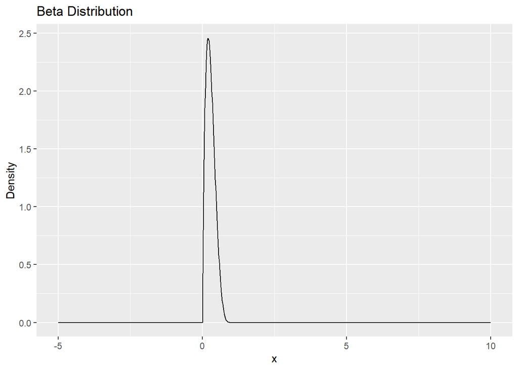

```r
ggplot(plot_beta, aes(x, beta_data)) +
  geom_line() +
  ggtitle("Beta Distribution") +
  xlab("x") + ylab("Density")
```

### Log-Normal Distribution

Results from taking the logarithm of a normally distributed random variable, often used in financial modeling.

```r
lognormal_data <- dlnorm(x, meanlog = 0, sdlog = 0.5)
plot_lognormal <- data.frame(x, lognormal_data)
```

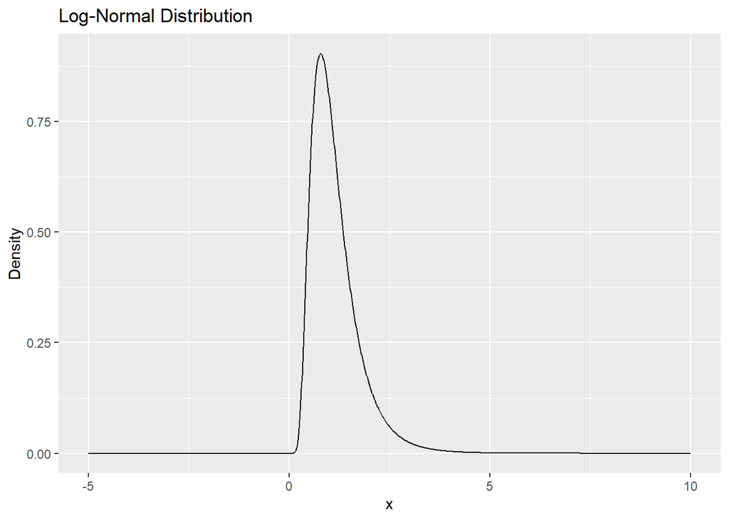

```r
ggplot(plot_lognormal, aes(x, lognormal_data)) +
  geom_line() +
  ggtitle("Log-Normal Distribution") +
  xlab("x") + ylab("Density")
```

### Weibull Distribution

Commonly used to model reliability and survival data.

```r
weibull_data <- dweibull(x, shape = 2, scale = 1)
plot_weibull <- data.frame(x, weibull_data)
```

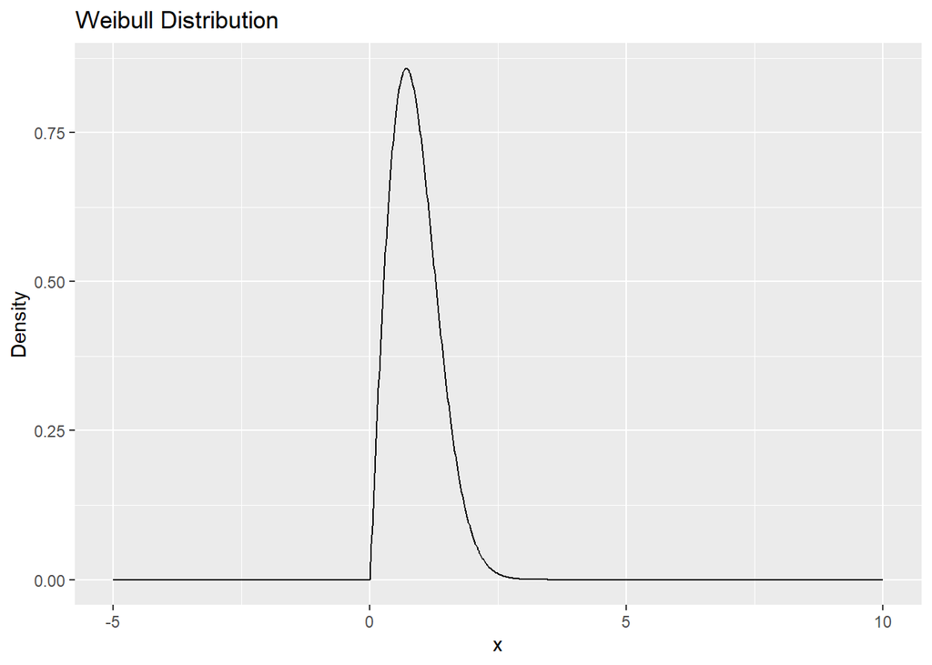

```r
ggplot(plot_weibull, aes(x, weibull_data)) +
  geom_line() +
  ggtitle("Weibull Distribution") +
  xlab("x") + ylab("Density")
```

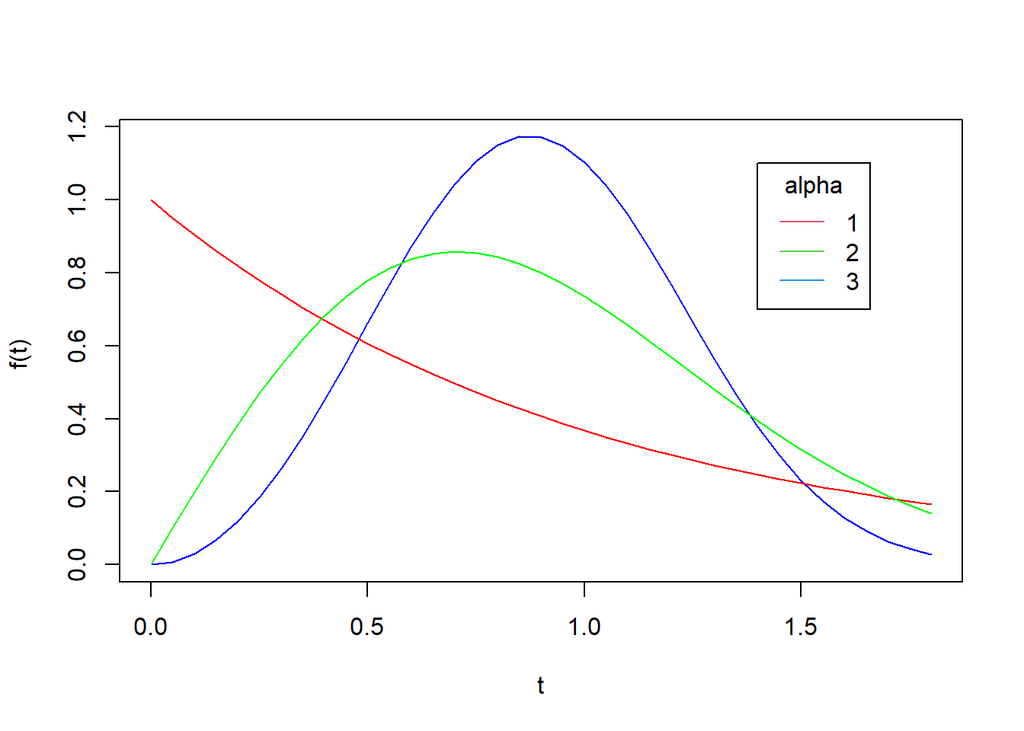

```r
a <- 3
l <- 1
t <- seq(0,1.8,.05)
ft <- a*l*t^(a-1)*exp(-l*t^a)
plot(t,ft,type="l",col="blue",ylab="f(t) ")
a <- 1
ft <- a*l*t^(a-1)*exp(-l*t^a)
lines(t,ft,type="l",col="red")
a <- 2
ft <- a*l*t^(a-1)*exp(-l*t^a)
lines(t,ft,type="l",col="green")
legend(1.4,1.1,c("1","2","3"),title="alpha",lty=c(1,1,1),col=c(2,3,4))
```

### T-Distribution

Used in hypothesis testing when the sample size is small and the population standard deviation is unknown.

```r
t_data <- dt(x, df = 5)
plot_t <- data.frame(x, t_data)
```

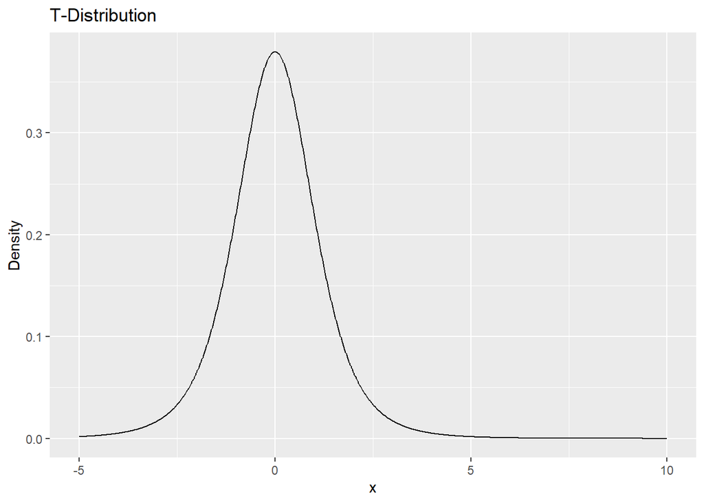

```r
ggplot(plot_t, aes(x, t_data)) +
  geom_line() +
  ggtitle("T-Distribution") +
  xlab("x") + ylab("Density")
```

### F-Distribution

Arises in the context of comparing variances from different populations.

```r
f_data <- df(x, df1 = 3, df2 = 8)
plot_f <- data.frame(x, f_data)
```

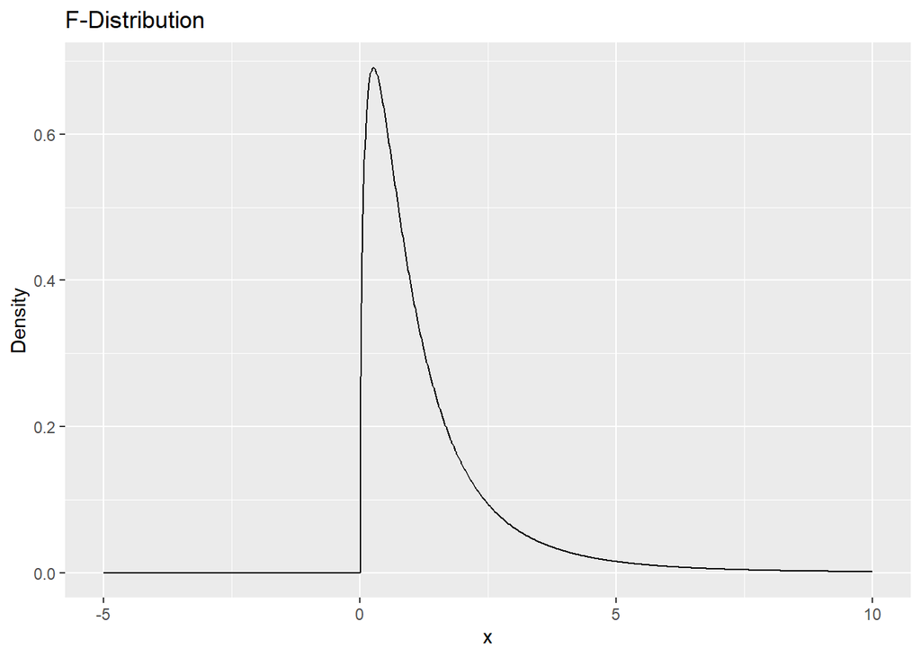

```r
ggplot(plot_f, aes(x, f_data)) +
  geom_line() +
  ggtitle("F-Distribution") +
  xlab("x") + ylab("Density")
```

## Discrete Distributions

### Bernoulli Distribution

The Bernoulli distribution models a binary outcome where an event can have only two possible outcomes: success (usually denoted as 1) with probability p or failure (usually denoted as 0) with probability q = 1 - p.

```r
# Set up the probabilities
p <- 0.3  # Probability of success
q <- 1 - p  # Probability of failure

# Create a data frame for the plot
bernoulli_data <- data.frame(x = c(0, 1), y = c(q, p))
```

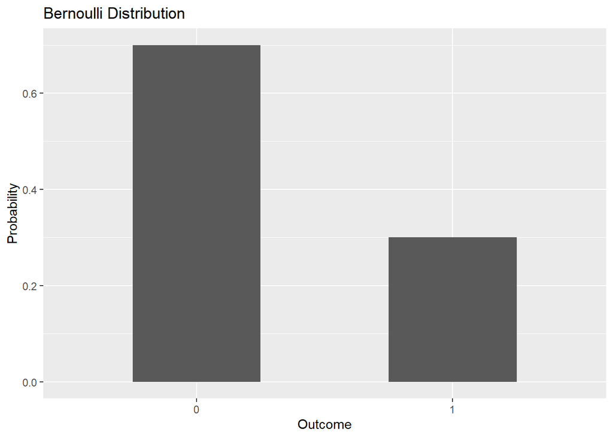

```r
# Create the plot
ggplot(bernoulli_data, aes(x = factor(x), y = y)) +
  geom_bar(stat = "identity", width = 0.5) +
  ggtitle("Bernoulli Distribution") +
  xlab("Outcome") + ylab("Probability")
```

### Binomial Distribution

The binomial distribution models the number of successes in a fixed number of independent Bernoulli trials. Each trial has two possible outcomes: success (usually denoted as 1) with probability p or failure (usually denoted as 0) with probability q = 1 - p. Here’s an example of how to plot the binomial distribution using R:

```r
# Set up parameters
n <- 10   # Number of trials
p <- 0.3  # Probability of success

# Generate x values representing the number of successes
x <- 0:n

# Compute the probabilities using the dbinom function
binomial_probs <- dbinom(x, size = n, prob = p)

# Create a data frame for the plot
binomial_data <- data.frame(x, binomial_probs)
```

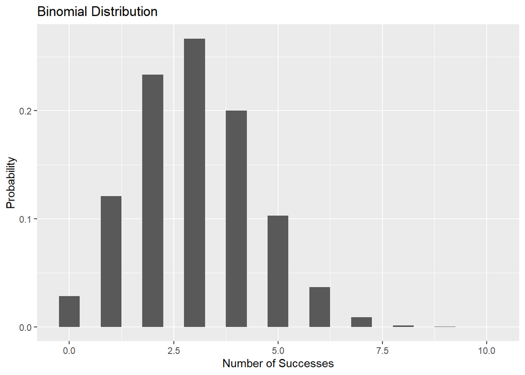

```r
# Create the plot
ggplot(binomial_data, aes(x, binomial_probs)) +
  geom_bar(stat = "identity", width = 0.5) +
  ggtitle("Binomial Distribution") +
  xlab("Number of Successes") + ylab("Probability")
```

### Poisson Distribution

The Poisson distribution models the number of events occurring in a fixed interval of time or space, given a known average rate of occurrence. Here’s an example of how to plot the Poisson distribution using R:

```r
# Set up parameter
lambda <- 3  # Average rate of occurrence

# Generate x values representing the number of events
x <- 0:20

# Compute the probabilities using the dpois function
poisson_probs <- dpois(x, lambda = lambda)

# Create a data frame for the plot
poisson_data <- data.frame(x, poisson_probs)
```

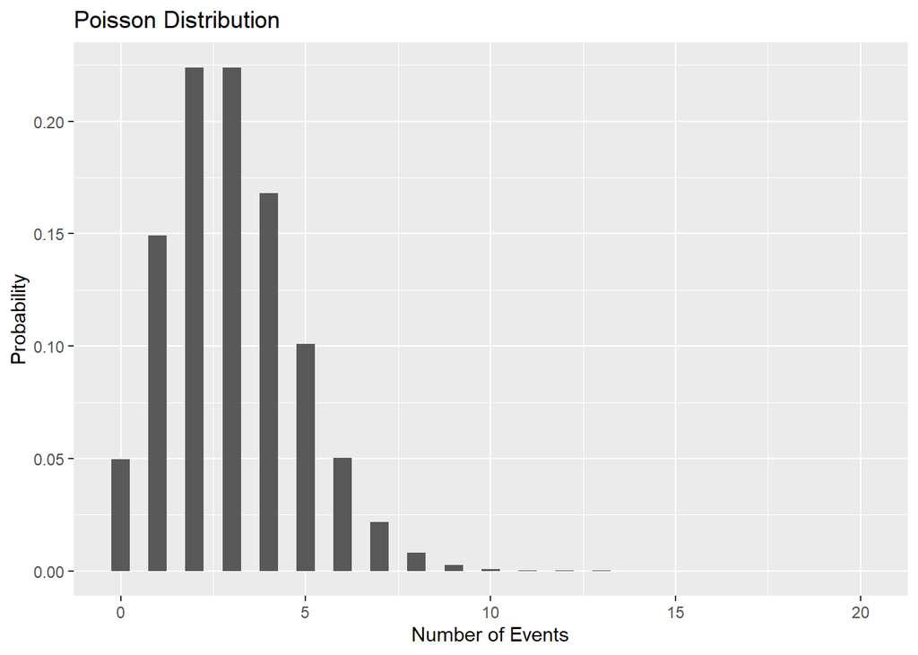

```r
# Create the plot
ggplot(poisson_data, aes(x, poisson_probs)) +
  geom_bar(stat = "identity", width = 0.5) +
  ggtitle("Poisson Distribution") +
  xlab("Number of Events") + ylab("Probability")
```

### Geometric Distribution

```r
# Set up parameter
p <- 0.2  # Probability of success

# Generate x values representing the number of trials needed
x <- 1:15

# Compute the probabilities using the dgeom function
geometric_probs <- dgeom(x, prob = p)

# Create a data frame for the plot
geometric_data <- data.frame(x, geometric_probs)
```

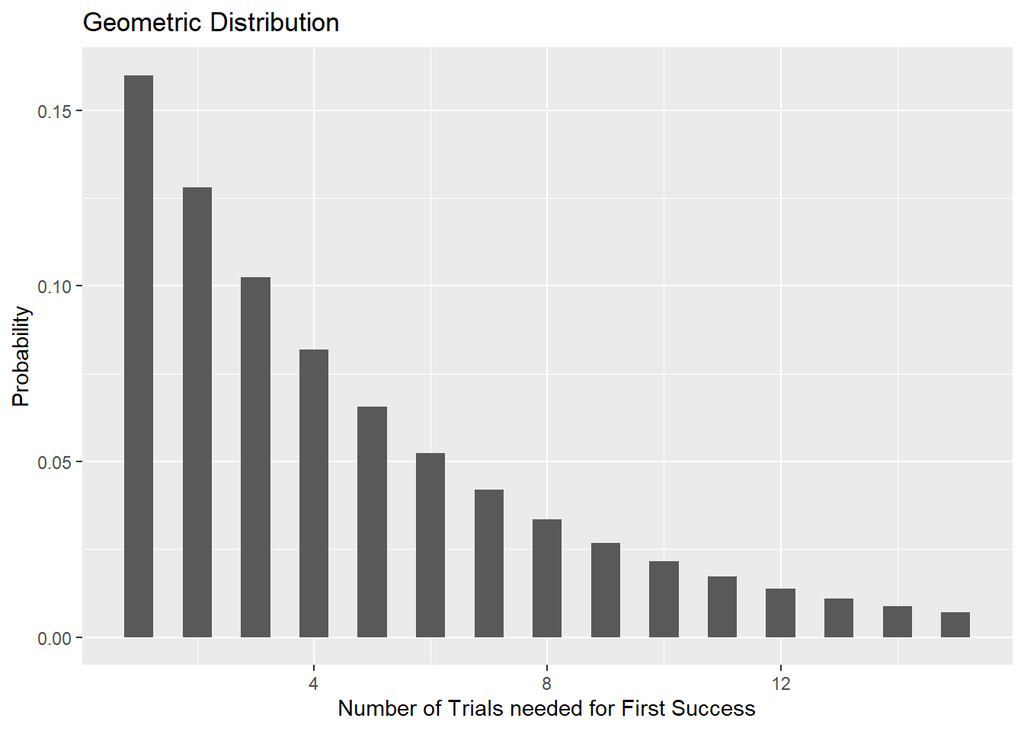

```r
# Create the plot
ggplot(geometric_data, aes(x, geometric_probs)) +
  geom_bar(stat = "identity", width = 0.5) +
  ggtitle("Geometric Distribution") +
  xlab("Number of Trials needed for First Success") + ylab("Probability")
```

### Negative Binomial Distribution

```r
# Set up parameters
k <- 5   # Number of successes
p <- 0.3 # Probability of success

# Generate x values representing the number of trials needed
x <- k:100

# Compute the probabilities using the dnbinom function
negative_binomial_probs <- dnbinom(x - k + 1, size = k, prob = p)

# Create a data frame for the plot
negative_binomial_data <- data.frame(x, negative_binomial_probs)
```

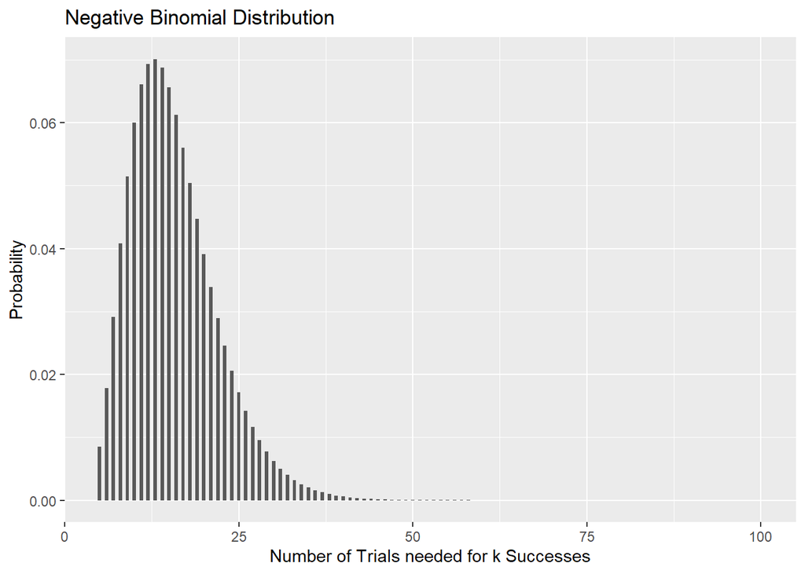

```r
# Create the plot
ggplot(negative_binomial_data, aes(x, negative_binomial_probs)) +
  geom_bar(stat = "identity", width = 0.5) +
  ggtitle("Negative Binomial Distribution") +
  xlab("Number of Trials needed for k Successes") + ylab("Probability")
```

### Hypergeometric Distribution

The hypergeometric distribution models the number of successes in a sample drawn without replacement from a finite population, where the items are divided into two classes (e.g., defective and non-defective items).

```r
# Set up parameters
N <- 50    # Total population size
K <- 15    # Number of success items in the population
n <- 10    # Sample size

# Generate x values representing the number of successes in the sample
x <- 0:n

# Compute the probabilities using the dhyper function
hypergeometric_probs <- dhyper(x, m = K, n = N - K, k = n)

# Create a data frame for the plot
hypergeometric_data <- data.frame(x, hypergeometric_probs)
```

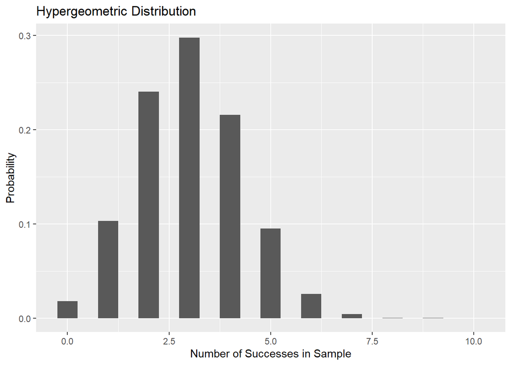

```r
# Create the plot
ggplot(hypergeometric_data, aes(x, hypergeometric_probs)) +
  geom_bar(stat = "identity", width = 0.5) +
  ggtitle("Hypergeometric Distribution") +
  xlab("Number of Successes in Sample") + ylab("Probability")
```

### Discrete Uniform Distribution

The discrete uniform distribution models equally likely outcomes over a finite range of values.

```r
# Set up parameters
a <- 1   # Minimum value in the range
b <- 6   # Maximum value in the range

# Generate x values representing the possible outcomes
x <- a:b

# Compute the probabilities (uniform for each value in the range)
uniform_probs <- rep(1 / (b - a + 1), length(x))

# Create a data frame for the plot
uniform_data <- data.frame(x, uniform_probs)
```

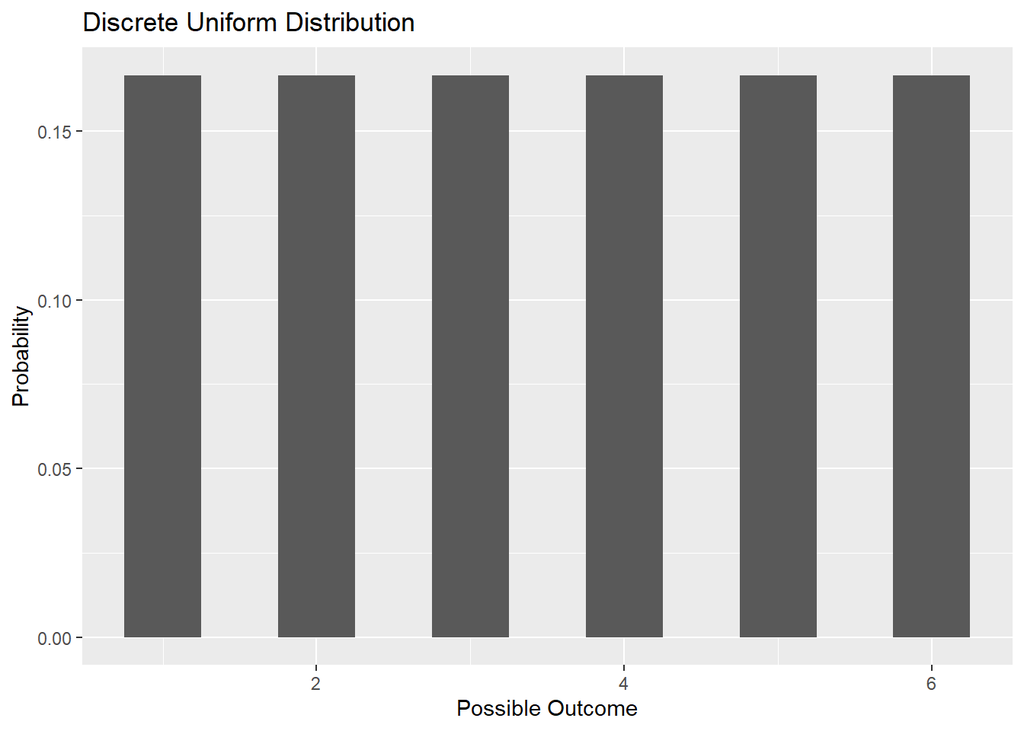

```r
# Create the plot
ggplot(uniform_data, aes(x, uniform_probs)) +
  geom_bar(stat = "identity", width = 0.5) +
  ggtitle("Discrete Uniform Distribution") +
  xlab("Possible Outcome") + ylab("Probability")
```

### Multinomial Distribution

The multinomial distribution generalizes the binomial distribution to more than two categories. It models the probability distribution of outcomes when conducting multiple independent trials, each with multiple possible outcomes.

```r
# Set up parameters
n <- 10
probs <- c(0.3, 0.4, 0.3)

# Generate possible outcomes matrix
outcomes <- expand.grid(replicate(length(probs), 0:(n - 1)))

# Calculate probabilities for each outcome
outcome_probs <- apply(outcomes, 1, function(outcome) {
  prod(sapply(1:length(probs), function(i) probs[i] ^ outcome[i]))
})

# Create a data frame for the plot
plot_data <- data.frame(outcome = 1:n,
                        probability = outcome_probs)
```

[figure not shown]

```r
# Create the plot
ggplot(plot_data, aes(x = factor(outcome), y = probability)) +
  geom_bar(stat = "identity", width = 0.5) +
  ggtitle("Multinomial Distribution") +
  xlab("Outcome") + ylab("Probability") +
  scale_x_discrete(labels = 1:n)
```